[figure not shown]

WI-463

Antenna Cord

WIRING SYSTEM

75.Antenna Cord

A: LOCATION

Connector Connecting to

No. Pole Color Area No. Description

AN1 3 GR B-3

Navigation unit

AN2 1 G B-3

AN3 3 B-2 AN5

Antenna cord

AN4 1 G B-2 AN6

AN5 3 B-2 AN3

AN6 1 G B-2 AN4

AN7 3 B-5 AN9

AN8 1 C-5 R97 Rear wiring harness LH

AN9 3 C-5 AN7 Antenna cord

AN11 3 GR B-5 AN15 Antenna

AN15 3 GR B-5 AN11 Antenna cord

: White or natural color

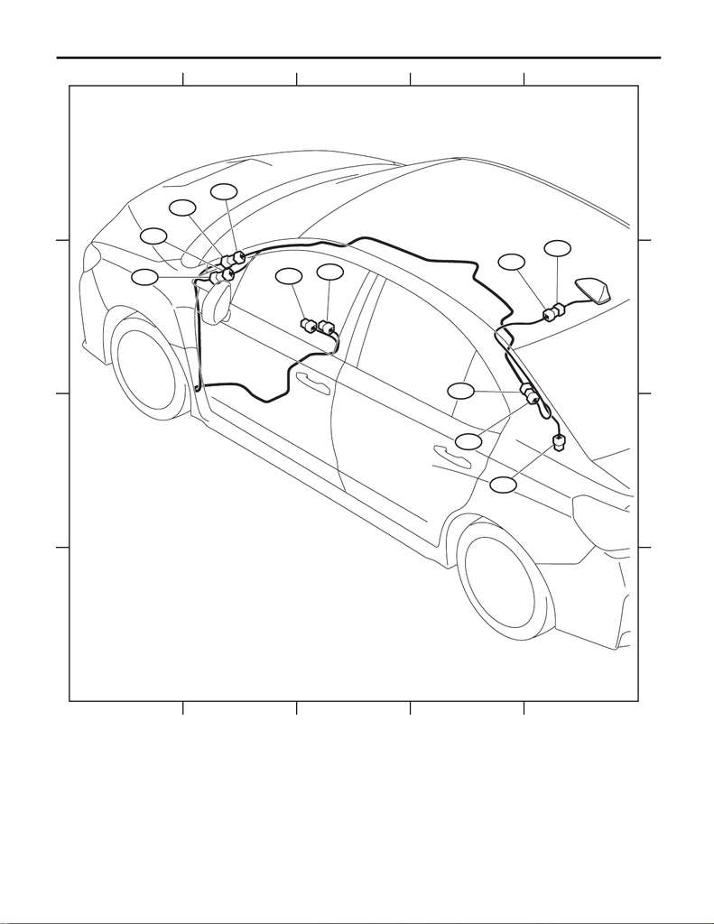

Antenna Cord

WIRING SYSTEM

A

B

C

D

A

B

C

D

AN11

AN2

AN4

AN5

AN3

AN6

AN1

AN7

AN9

AN8

AN15